# Misturas Finitas

Autor

Milena Paz Freitas

## 1. Definição

De acordo com Everitt (2013), misturas de densidades podem ser difinidas da seguinte forma:

Seja $g(\bm{x};\bm{ \theta})$ uma função densidade de probabilidade d-dimensional, $\bm{\theta}$ um vetor de parâmetros m-dimensional e $H(\bm{\theta})$ uma função distribuição acumulada m-dimensional. Então:

$$f(\bm{x})= \int g(\bm{x};\bm{\theta}) dH(\bm{\theta})$$

é chamada de densidade mistura.

No caso de $H$ possuir distribuição discreta finita, temos que $f$ pode ser reescrita em forma de somatório, como descrito por Rodrigo Basso (2010):

$$f(\bm{x}) = \sum^n_{i=1}\omega_ig_i(\bm{x}),\quad0 \leq \omega_i \leq 1\quad \text{e } \sum^n_{i=1}\omega_i =1$$

Temos que $f(\bm{x})$ é uma mistura de densidades finita com n componentes, $\omega_i$ são as proporções (ou pesos) de mistura e $g_i$ são as componentes. No caso das densidades $g_i$ pertencerem à mesma família paramétrica com $\bm{\theta_i}\in\Theta$, podemos denotá-las como $g_i(\bm{x}|\bm{\theta_i})$.

É importante notar que componentes de misturas não são necessariamente contínuas, existem misturas de componentes Bernoulli, Poisson, etc.

## 2. Exemplos

### 2.1 Misturas normais (Gaussianas)

Chamamos de misturas normais aquelas que são compostas apenas por densidades da família normal, com $\bm{\theta_i}=(\mu_i,\sigma_i)^\top$, onde $\mu \in \mathbb{R}$ e $\sigma >0$. Interpretando a distribuição dos “pesos” como uma variável categórica que separa as componentes em grupos, podemos modelar muitos fenômenos reais por meio de misturas normais.

Alguns exemplos de misturas e seus gráficos:

1. $0.51\mathcal{N}(160, 15) + 0.49\mathcal{N}(173, 12)$

**Código**

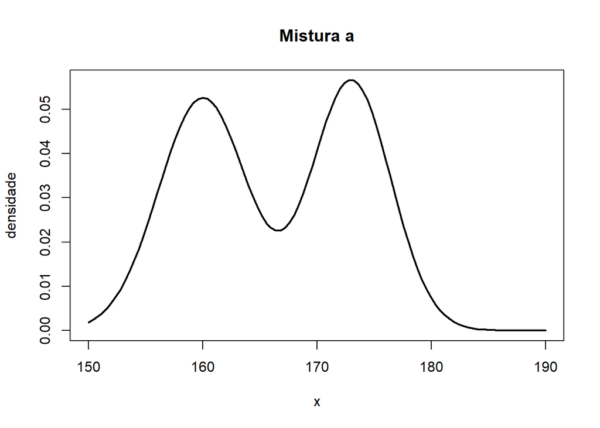

```r
curve(.51*dnorm(x,160,sqrt(15))+.49*dnorm(x,173,sqrt(12)),
      main= "Mistura a",ylab="densidade",
      from=150,to=190,lwd=2)
```

Essa distribuição é inspirada nas alturas dos brasileiros, com a média de alturas femininas sendo menor que das masculinas e os pesos sendo aproximadamente iguais; ou seja, o sexo seria a categoria dividindo os grupos. Este gráfico apresenta dois picos, caracterizando-o como bimodal.

2. $\displaystyle{\sum_{k=0}^7 \frac{1}{8} \mathcal{N}\left( 3\left[ \left(\frac{2}{3}\right)^k -1\right], \left(\frac{2}{3}\right)^{2k} \right)}$

Para implementar essa mistura no R, foi conveniente criar a seguinte função por conta do grande número de componentes:

```r
dMisturaNorm <- function(x,mi,dp,probs){
  #---------------------------------------#
  # x: vetor de valores a serem avaliados #
  # mi: vetor de médias                   #
  # dp: vetor de desvios padrão           #
  # probs: vetor de pesos das componentes #
  #---------------------------------------#
  n <- length(mi)
  if(length(x)==1)
    #caso especial, quando x não é vetor
    return(sum(probs*dnorm(x,mi,dp)))
  return(rowSums(sapply(1:n,function(k) probs[k]*dnorm(x,mi[k],dp[k]))))
}
```

**Código**

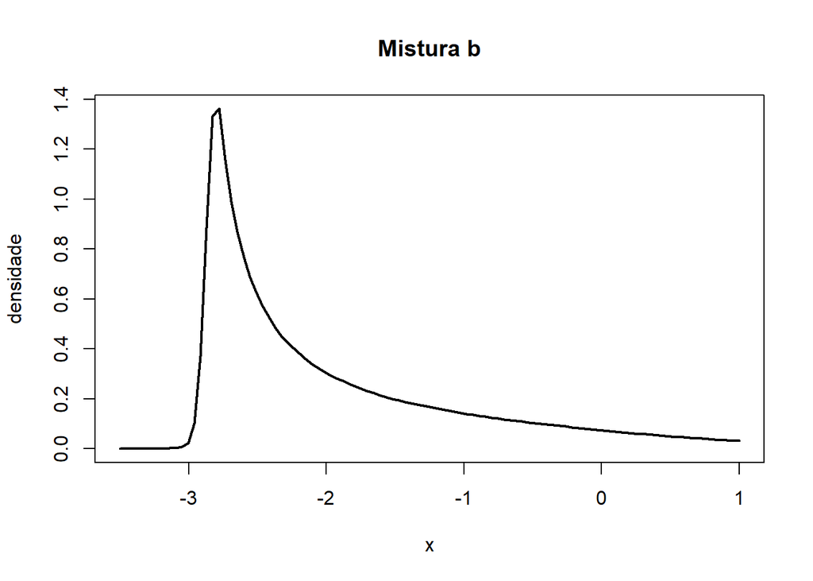

```r
#implementação da mistura:
mi <- 3*( (2/3)^(0:7) - 1)
vars <- (2/3)^(2*(0:7))
pesos <- rep(1/8,8)

curve(dMisturaNorm(x,mi,sqrt(vars),pesos),
      main= "Mistura b",ylab="densidade",
      from=-3.5,to=1,lwd=2)
```

É uma densidade altamente assimétrica à direita, desassemelha-se muito de uma aparência normal.

### 2.2. Misturas discretas

Além das misturas de densidades, é possível elaborar misturas de distribuições discretas, como Geométricas, Poisson, Binomiais, etc. Seguem exemplos de algumas:

3. $$f_X(j)=P(X=j)= \left( \frac{1}{2} \right)^{j+1}
   +\frac{\left( \frac{1}{2} \right)2^{j-1}}{3^j},\quad j=1,2,...$$

Podemos observar que essa função de probabilidade é a mistura de duas geométricas:

$\frac{1}{2}\text{Geom}(1/2)+ \frac{1}{2}\text{Geom}(1/3)$

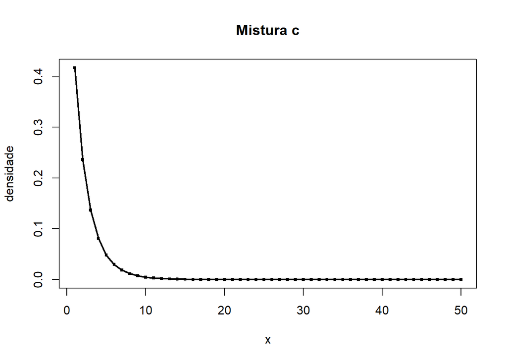

```r
# note que foi usado o valor de x-1, pois a parametrização do R difere da minha
x<- 1:50
plot(.5*dgeom(x-1,1/2)+.5*dgeom(x-1,1/3),
    type="o",pch=".",cex=4,
    main= "Mistura c",ylab="densidade",xlab="x",lwd=2)
```

4. $0.15\text{Pois}(3) + 0.75\text{Pois}(10) + 0.1\text{Pois}(1.5)$

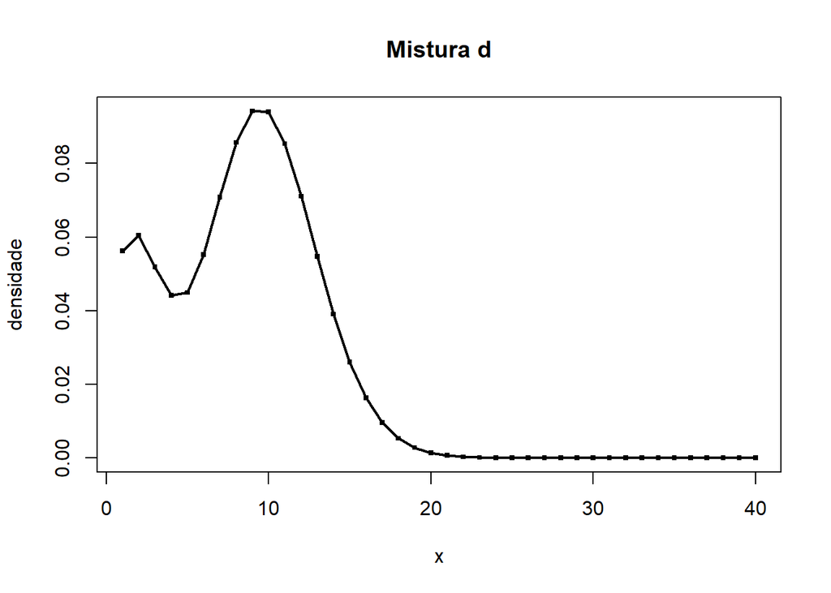

```r
x<- 1:40
plot(.15*dpois(x,3)+.75*dpois(x,10)+.1*dpois(x,1.5),
     type="o",pch=".",cex=4,
     main= "Mistura d",ylab="densidade",xlab="x",lwd=2)
```

### 2.3. Misturas de diferentes famílias paramétricas

Como visto na definição, são possíveis misturas de diferentes famílias paramétricas, como a que segue:

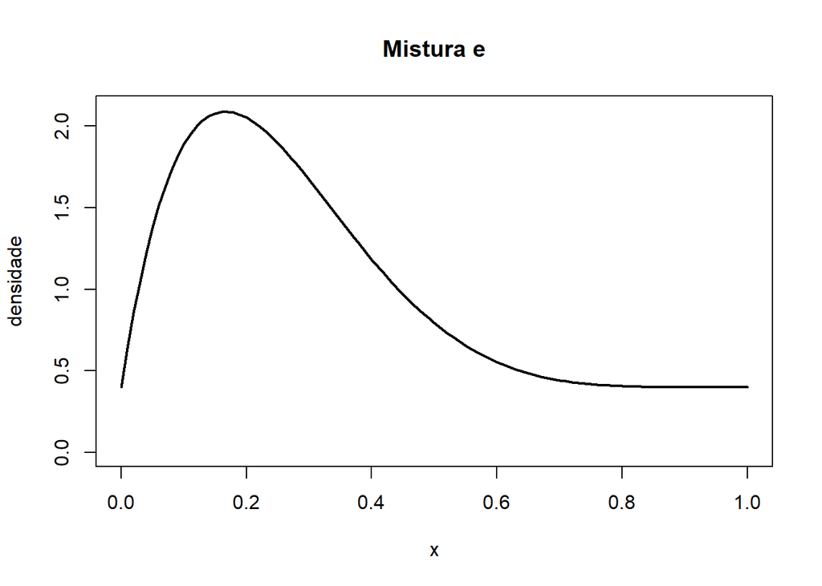

```r
curve(0.4*dunif(x)+0.6*dbeta(x,2,6),
      main= "Mistura e",ylab="densidade",
      lwd=2,ylim=c(0,2.1))
```

Essa mistura visualmente se assemelha à densidade da Beta, mas “levantada” por conta da Uniforme.

## 3. Gerando amostras de misturas finitas

Para gerar misturas, são dois passos:

- Gerar números que definirão qual componente será gerada.
  - Isso pode ser feito gerando números uniformemente de 0 a 1 e, de acordo com sua posição no intervalo (tomando como referência a soma cumulativa dos pesos $\omega$), definir qual componente gerar.
  - Alternativamente, pode ser gerada uma multinomial com os pesos de parâmetro.
- Gerar a componente correspondente a cada número gerado.

### 3.1 Implementação

Como exemplo serão usadas as misturas *a* e *b* da subseção 2.1 para geração.

#### Método I)

O primeiro passo será feito usando geração de números $\text U (0,1)$, como segue:

```r
rMisturaNorm <- function(n,mi,dp,probs){
  k<- length(mi)
  X<- numeric(n)
  U <- runif(n)
  p <- cumsum(c(0,probs))
  for(i in 1:k){
    caso <- U <= p[i+1] & U> p[i]
    tam <- sum(caso)
    X[caso] <- rnorm(tam,mi[i],dp[i])
  }
  return(X)
}#Fim função geradora
```

- **Mistura a:**

$$0.51\mathcal{N}(160, 15) + 0.49\mathcal{N}(173, 12)$$

```r
n <- 200
mi <- c(160,173)
dp <- sqrt(c(15,12))
pesos <- c(.51,0.49)

X1 <- rMisturaNorm(n,mi,dp,pesos)
```

Histograma e comparação com a densidade:

**Código**

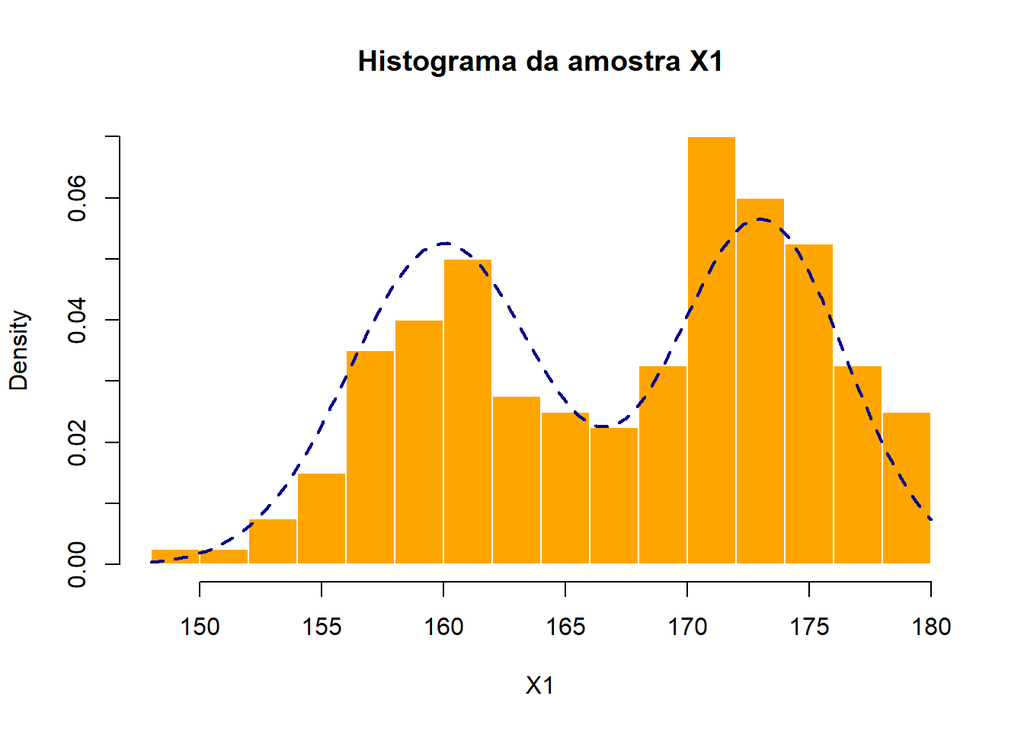

```r
hist(X1, freq=F, breaks=20,col="orange",border="white",main="Histograma da amostra X1")
curve(dMisturaNorm(x,mi,dp,pesos),
      add=T,col="darkblue",lty=2,lwd=2)
```

- **Mistura b:**

$$\sum_{k=0}^7 \frac{1}{8} \mathcal{N}\left( 3\left[ \left(\frac{2}{3}\right)^k -1\right], \left(\frac{2}{3}\right)^{2k} \right)$$

```r
mi <- 3*( (2/3)^(0:7) - 1)
dp <- sqrt((2/3)^(2*(0:7)))
pesos <- rep(1/8,8)

X2 <- rMisturaNorm(n, mi, dp, pesos)
```

Histograma e comparação com a densidade:

**Código**

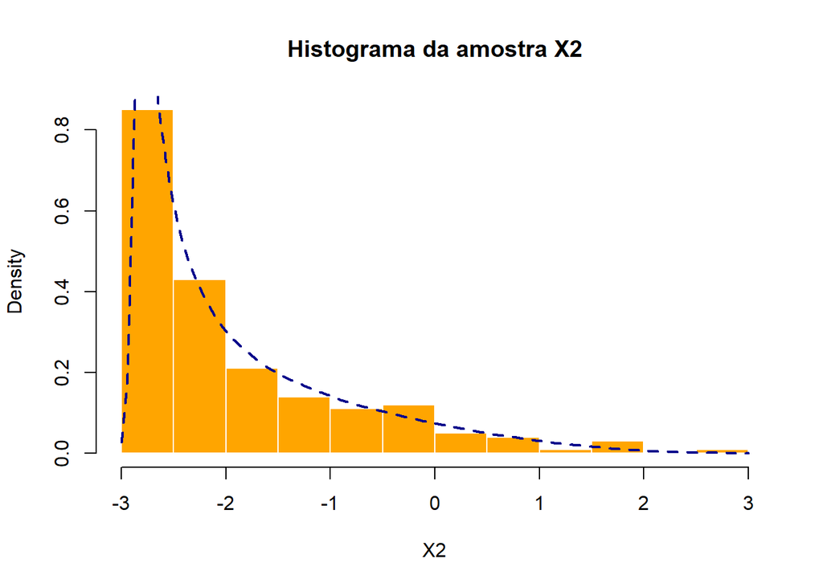

```r
hist(X2, freq=F, breaks=20,col="orange",border="white",main="Histograma da amostra X2")
curve(dMisturaNorm(x,mi,dp,pesos),
      add=T,col="darkblue",lty=2,lwd=2)
```

#### Método II)

Agora o mesmo processo será feito usando uma multinomial no lugar da uniforme:

```r
rMisturaNormAlt <- function(n,mi,dp,probs){
  k<- length(mi)
  X<- numeric(n)
  tam <- as.vector(rmultinom(1,n,probs))
  lims <- cumsum(c(0,tam))
  for(i in 1:k){
    X[(lims[i]+1):lims[i+1]] <- rnorm(tam[i],mi[i],dp[i])
  }
  return(X)
}#Fim função geradora
```

- **Mistura a:**

```r
n <- 200
mi <- c(160,173)
dp <- sqrt(c(15,12))
pesos <- c(.51,0.49)

X3 <- rMisturaNormAlt(n,mi,dp,pesos)
```

Histograma e comparação com a densidade:

**Código**

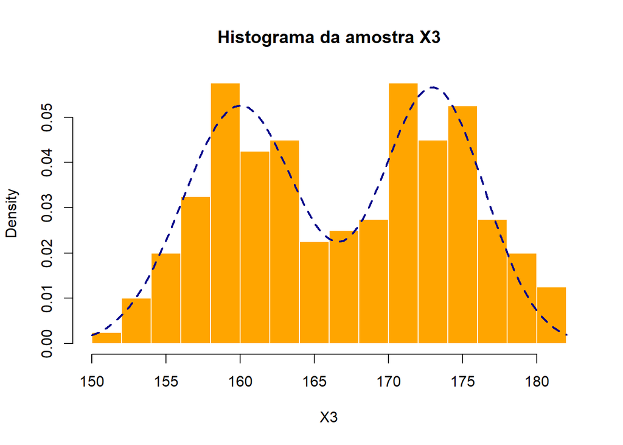

```r
hist(X3, freq=F, breaks=20,col="orange",border="white",main="Histograma da amostra X3")
curve(dMisturaNorm(x,mi,dp,pesos),
      add=T,col="darkblue",lty=2,lwd=2)
```

- **Mistura b:**

```r
mi <- 3*( (2/3)^(0:7) - 1)
dp <- sqrt((2/3)^(2*(0:7)))
pesos <- rep(1/8,8)

X4 <- rMisturaNormAlt(n, mi, dp, pesos)
```

Histograma e comparação com a densidade:

**Código**

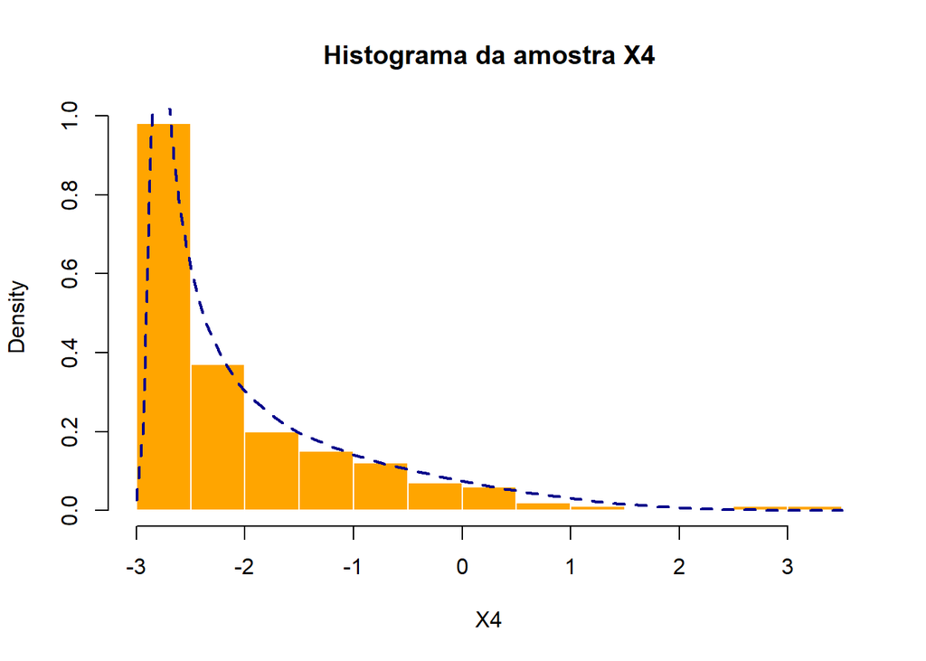

```r
hist(X4, freq=F, breaks=20,col="orange",border="white",main="Histograma da amostra X4")
curve(dMisturaNorm(x,mi,dp,pesos),
      add=T,col="darkblue",lty=2,lwd=2)
```

Os mesmos gráficos, dispostos lado a lado:

**Código**

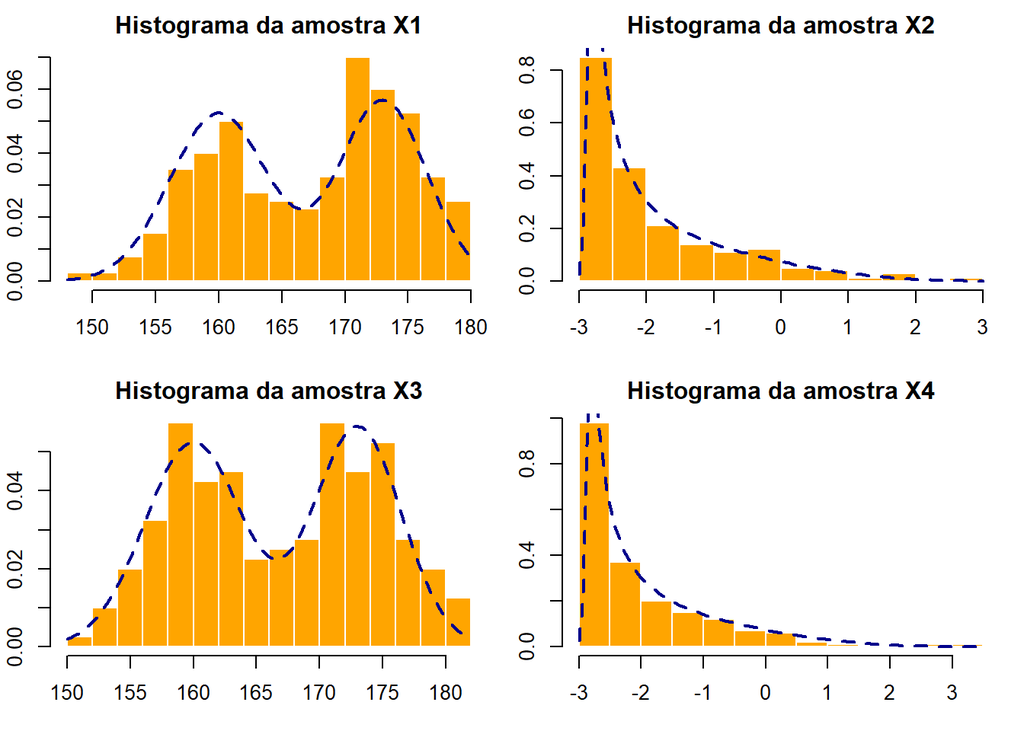

```r
par(mfrow=c(2,2),mar=c(3.1,2.1,2,1))
amostras <- list(X1,X2,X3,X4)
for(i in 1:4){
  hist(amostras[[i]], freq=F, breaks=20,
       col="orange",border="white",main=paste0("Histograma da amostra X",i))
  if(i%%2==0){
    mi <- 3*( (2/3)^(0:7) - 1)
    dp <- sqrt((2/3)^(2*(0:7)))
    pesos <- rep(1/8,8)
  }
  else{
    mi <- c(160,173)
    dp <- sqrt(c(15,12))
    pesos <- c(.51,0.49)
  }
  curve(dMisturaNorm(x,mi,dp,pesos),
      add=T,col="darkblue",lty=2,lwd=2)
}
```

## Referências

BASSO, R. M.; DÁVILA, V. H. L. **Misturas finitas de misturas de escala skew-normal**. tese de doutorado—SP: Dissertação de Mestrado-Universidade Estadual de Campinas, 2010.

EVERITT, B. **Finite mixture distributions**. [s.l.] Springer Science & Business Media, 2013.